# Projet apprentissage statistiques - Etude SpeedDating

## XGBOOST (Modèle 4/5)

## XGBOOST

Les hyperparamètres à optimiser sont :

- le nombre d’itération du boosting
- la profondeur maximale des arbres
- le pas de descente de gradient
- le pourcentage de variable qu’on garde pour la onstruction arbre
- la taille des sous-échantillons
- le gain minimum pour diviser un noeud

## XGBOOST Evaluation

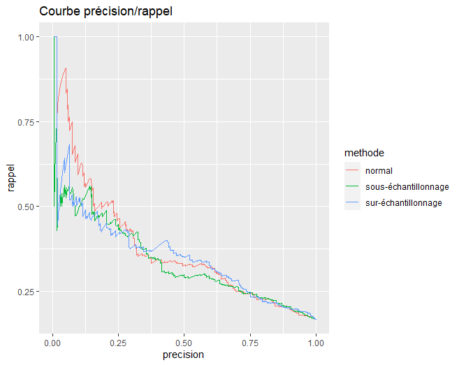

### Précision rappel

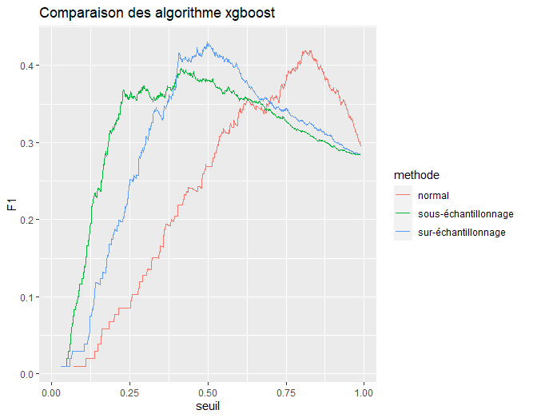

### F1-score en fonction du seuil

## XGBOOST Matrice de confusion

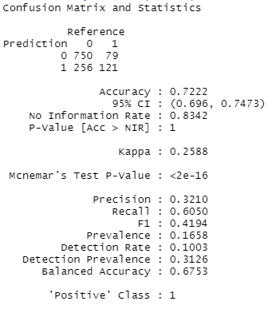

### Xgboost

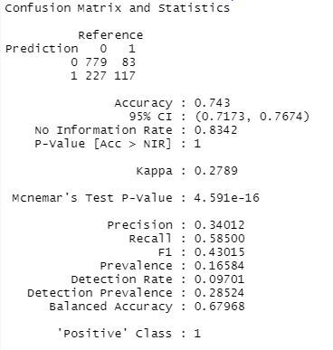

#### Xgboost sur-échantillonnage

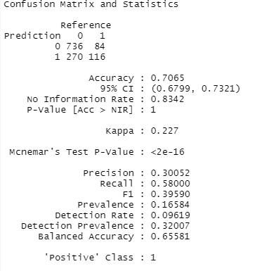

#### Xgboost sous-échantillonnage

## Intelligence artificielle (Modèle 5/5)

## Intelligence artificielle

- Réseaux de neurones : neurones d’entrées et de sortie
- Couches de neurones cachées
- Fonction d’activation
- Fonction de perte

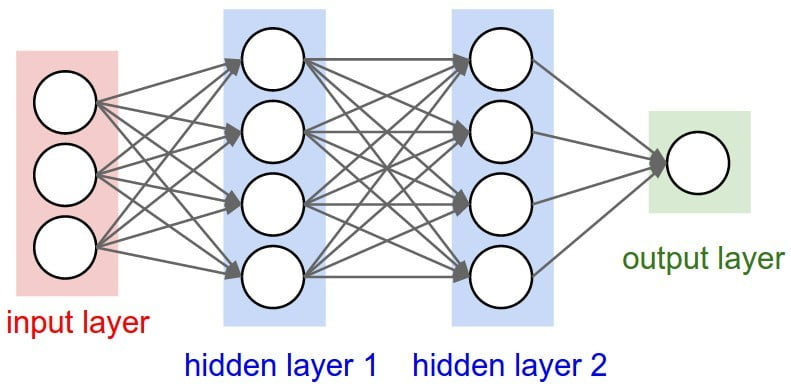

## Méthode : Fonction de perte “focal loss”

- Déséquilibre > trouver une fonction de perte adéquate
- Fonction de perte : “focal loss”
- Voici la formule pour cette fonction de perte :

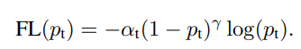

Hyperparamètres : \({\gamma}\)

## Méthode : Fonction de perte “focal loss”

- Architecture :
  - 3 couches (139, 97, 42)
  - Fonction d’activation : sigmoid
  - Fonction de perte : focal loss
  - gamma = 2

## Méthode : Fonction de perte “focal loss”

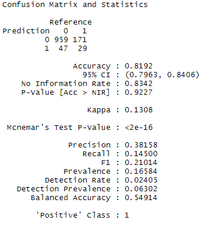

## Méthode : poids

- Fonction de perte instable > autre solution
- Mettre des différents poids sur les classes
- Formule pour les poids :
  - nombre de la plus grande classe/nombre de la classe i
- Hyperparamètres classique d’IA
- Architecture :
  - 3 couches (88, 16, 16)
  - Fonction d’activation : sigmoid
  - Fonction de perte : Binary crossentropy

## Méthode : poids

- F1_Score seuil 0.5 : 0.358
- F1_score meilleur seuil : 0.363

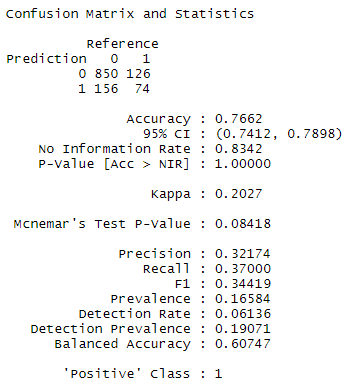

## Méthode ROSE

- Autres méthodes ? Rééchantillonage ROSE
- Avantage : retomber sur un cas classique d’un problème équilibré
- Architecture :
  - 3 couches (139, 97, 42)
  - Fonction d’activation : sigmoid
  - Fonction de perte : Binary crossentropy

## Méthode ROSE

- F1_Score seuil 0.5 : 0.38
- F1_score meilleur seuil : 0.395

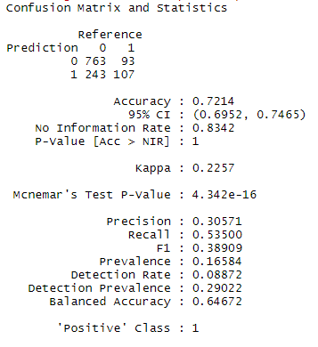

## Méthode suréchantillonage

- Rééchantillonage : oversampling
- Architecture :
  - 3 couches cachées (111, 70, 21)
  - Fonction d’activation : sigmoid
  - Fonction de perte : Binary crossentropy

## Méthode suréchantillonage

- F1_Score seuil 0.5 : 0.38
- F1_score meilleur seuil : 0.384

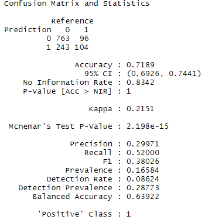

## Comparaison des algos

## Comparaison des algos

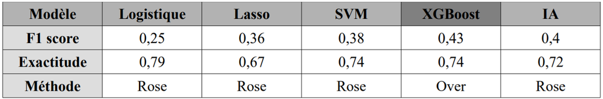

## Quelques mots pour comparer les algos

- Essai de combinaison des modèles entre IA et XGBoost
  - Vote à la majorité avec pondération et choix du meilleur seuil pour maximiser le F1_score

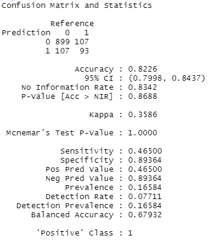

## Conclusion

## Conclusion

- Projet compliqué mais très intéressant
  - car beaucoup de variables très peu corréles
  - déséquilibre
- Peut-être moyen de trouver mieux avec IA et combinaison de modèle
- Application R-Shiny